# IODS course project

Minna Maunula

# Introduction to Open Data Science - Course Project

## About the project

This is a course on Open Data Science.

## Course decription

More information can be found from [here]:(https://studies.helsinki.fi/courses/course-implementation/hy-opt-cur-2324-6bc9901d-e80d-4ba7-8bce-829e42c15521/PHD-302)

```r
date()
```

```
## [1] "Mon Dec  4 23:27:02 2023"
```

I have only completed so far reading and exercises from chapter 1 and 2 and I’m panicking a little. For me it was difficult to understand how the course starts and I was confused what to complete. Also, I didn’t remember how much work 5 credits course can be :) I expect to learn how to use Github and understand R code. I heard about the course from university email.

The crash course is excellent, easy to follow and understand, but I should have had more time to go it trough, because everything was new to me. So far I have only completed chapters 1 and 2.

**Github** My GitHub repository is [here](https://github.com/minmaunu/IODS-project)

# Assignment 2: Data Analysis excercise

*This week I have completed the Excercise2.Rmd, Data wrangling excercise and Data analysis where I learned some data wrangling, like modifying data sets, extracting and combining desired variables into a new data set, how to check the data, do some statistical tests and visualizations. I also spent a lot of time learning new words and concepts to better understand these statistical analyses.*

- Aim of this analysis is to interpret a ready made data set that is available in this website: https://raw.githubusercontent.com/KimmoVehkalahti/Helsinki-Open-Data-Science/master/datasets/learning2014.txt

```r
date()
```

```
## [1] "Mon Dec  4 23:27:02 2023"
```

## Getting to know the data

- First lets read the data into a data frame in R using command read.csv() and name it as students2014.
- Then we can check the dimension using dim() command and structure using str() command

### R code

```r
students2014 <- read.csv("https://raw.githubusercontent.com/KimmoVehkalahti/Helsinki-Open-Data-Science/master/datasets/learning2014.txt")

dim(students2014)
```

```
## [1] 166   7
```

```r
str(students2014)
```

```
## 'data.frame':    166 obs. of  7 variables:
##  $ gender  : chr  "F" "M" "F" "M" ...
##  $ age     : int  53 55 49 53 49 38 50 37 37 42 ...
##  $ attitude: num  3.7 3.1 2.5 3.5 3.7 3.8 3.5 2.9 3.8 2.1 ...
##  $ deep    : num  3.58 2.92 3.5 3.5 3.67 ...
##  $ stra    : num  3.38 2.75 3.62 3.12 3.62 ...
##  $ surf    : num  2.58 3.17 2.25 2.25 2.83 ...
##  $ points  : int  25 12 24 10 22 21 21 31 24 26 ...
```

- Data has 166 rows (observations) and 7 columns (variables)
- age and points variables are type integers (int) that indicate numerical values, gender variable is a type character (chr) that is categorical character with two variables: female or male. Rest of the variables (attitude, deep, stra and surf) are numerical variables with different scales.

## Data visualization

- First let’s check the summaries of the variables in the data using summary() commmand
- Next let’s see a graphical overview of the data using **ggplot2** library and creating a scatter plot

### R code

```r
# students2014 is available

# Access the gglot2 library
library(ggplot2)

# Summary of numeric variables
summary(students2014)
```

```
##     gender               age           attitude          deep
##  Length:166         Min.   :17.00   Min.   :1.400   Min.   :1.583
##  Class :character   1st Qu.:21.00   1st Qu.:2.600   1st Qu.:3.333
##  Mode  :character   Median :22.00   Median :3.200   Median :3.667
##                     Mean   :25.51   Mean   :3.143   Mean   :3.680
##                     3rd Qu.:27.00   3rd Qu.:3.700   3rd Qu.:4.083
##                     Max.   :55.00   Max.   :5.000   Max.   :4.917
##       stra            surf           points
##  Min.   :1.250   Min.   :1.583   Min.   : 7.00
##  1st Qu.:2.625   1st Qu.:2.417   1st Qu.:19.00
##  Median :3.188   Median :2.833   Median :23.00
##  Mean   :3.121   Mean   :2.787   Mean   :22.72
##  3rd Qu.:3.625   3rd Qu.:3.167   3rd Qu.:27.75
##  Max.   :5.000   Max.   :4.333   Max.   :33.00
```

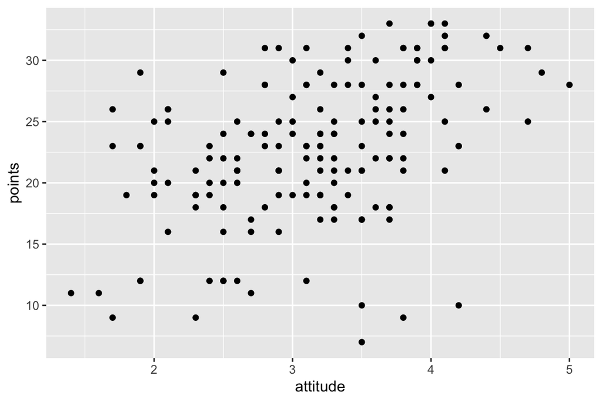

```r
# initialize plot with data and aesthetic mapping
p1 <- ggplot(students2014, aes(x = attitude, y = points))

# define the visualization type (points)
p2 <- p1 + geom_point()

# draw the plot
p2
```

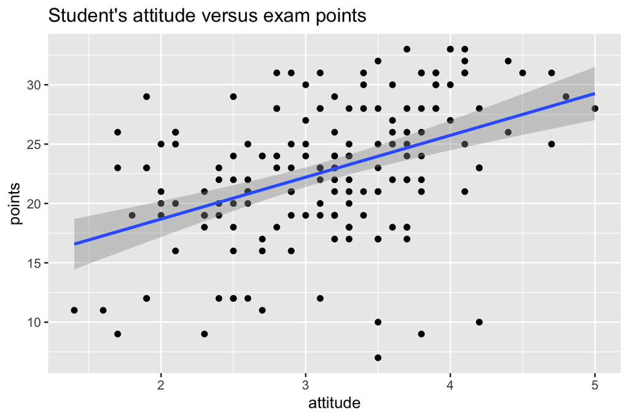

```r
# add a regression line
p3 <- p2 + geom_smooth(method = "lm")

# add a main title
p4 <- p3 + ggtitle("Student's attitude versus exam points")

# draw the plot!
p4
```

## Statistical test to interpret a statistically significant relationship with the explanatory variable and target variables

- Let’s choose three variables (age, attitude, and deep) as explanatory variables, and points as the target variable and form a linear regression model from those.

### R code

```r
# students2014 is available

# Access the gglot2 library
library(ggplot2)

model <- lm(points ~ age + attitude + deep, data = students2014)

# Summary of the fitted model
summary(model)
```

```
##
## Call:
## lm(formula = points ~ age + attitude + deep, data = students2014)
##
## Residuals:
##     Min      1Q  Median      3Q     Max
## -17.206  -3.430   0.204   3.979  10.950
##
## Coefficients:
##             Estimate Std. Error t value Pr(>|t|)
## (Intercept) 15.60773    3.38966   4.605 8.32e-06 ***
## age         -0.07716    0.05322  -1.450    0.149
## attitude     3.59413    0.56959   6.310 2.56e-09 ***
## deep        -0.60275    0.75031  -0.803    0.423
## ---
## Signif. codes:  0 '***' 0.001 '**' 0.01 '*' 0.05 '.' 0.1 ' ' 1
##
## Residual standard error: 5.307 on 162 degrees of freedom
## Multiple R-squared:  0.2043, Adjusted R-squared:  0.1896
## F-statistic: 13.87 on 3 and 162 DF,  p-value: 4.305e-08
```

```r
model2 <- lm(points ~ attitude, data = students2014)

# Summary of the fitted model2
summary(model2)
```

```
##
## Call:
## lm(formula = points ~ attitude, data = students2014)
##
## Residuals:
##      Min       1Q   Median       3Q      Max
## -16.9763  -3.2119   0.4339   4.1534  10.6645
##
## Coefficients:
##             Estimate Std. Error t value Pr(>|t|)
## (Intercept)  11.6372     1.8303   6.358 1.95e-09 ***
## attitude      3.5255     0.5674   6.214 4.12e-09 ***
## ---
## Signif. codes:  0 '***' 0.001 '**' 0.01 '*' 0.05 '.' 0.1 ' ' 1
##
## Residual standard error: 5.32 on 164 degrees of freedom
## Multiple R-squared:  0.1906, Adjusted R-squared:  0.1856
## F-statistic: 38.61 on 1 and 164 DF,  p-value: 4.119e-09
```

## Explanation of the relationship between the chosen explanatory variables and the target variable and the multiple R-squared of the model

- Based on summary we can see a summary of the fitted model, including coefficients, standard errors, t-values, and p-values.
- If the coefficient is positive it indicates a positive relationship, and if it’s negative, it indicates a negative relationship between the target variable (points) and explanatory variable (age, attitude or deep)
- The standard errors measure the variability of the estimated coefficients.
- Smaller the standard errors are, usually means more precise estimates.
- t-value can be calculated by dividing the coefficient by its standard error. Results can be excepted to be significant, the higher the t-values are.
- If p-value is below treshold of 0.05 (that is commonly used) the variable can be assumed to be statistically significant. Smaller the p-value, stronger the evidence against the null hypothesis. In this fitted model the p-value for attitude is very low (4.12e-09) –> so age and deep variables were removed.
- The multiple R-squared is 0.1906. This means that approximately 19.06% of the variability in exam points is explained by the attitude variable.
- Lastly, there is a lot of variability in exam points, but only with these factors it’s impossible to know why. –> Some other factors in the original data set could explain this variability better.

## Diagnostic plots: Residuals vs Fitted values, Normal QQ-plot and Residuals vs Leverage.

### R code

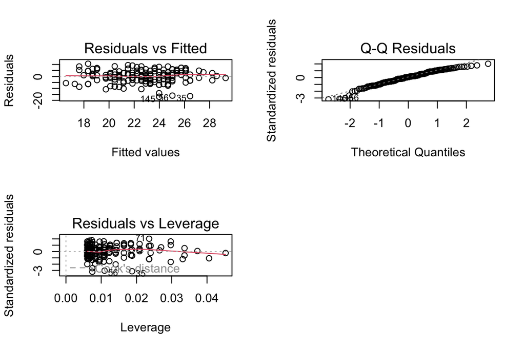

```r
# students2014 and model2 is available

# Place the following 4 graphics to one plot with plot layout of 2x2
par(mfrow = c(2,2))

# draw diagnostic plots using the plot() function. Choose the plots 1, 2 and 5
plot(model2, which = c(1, 2, 5))
```

## Explanation of the assumptions of the model and interpret the validity of those assumptions based on the diagnostic plots

1. Plot on Residuals vs Fitted Values: If the relationship between fitted values and residuals are uncorrelated, they should form linear model. So the relationship between residuals and fitted values is random and without a clear pattern. If it something else than linear (like curve or funnel) it indicates broken linearity assumption. –> Conclusions: Points are scattered and no specific pattern is shown. Plot seems also linear. Linearity assumption is valid.
2. Normal QQ-plot: Normal QQ-plot is used to check whether or not a set of data follows a normal distribution. If it does, the points should form a straight line. However, is the points deviate the data is less likely to follow a normal distribution.–> Conclusions: The points follow the diagonal line pretty well, but some deviations can be seen in the “tails”. Still, it’s ok to assume that the data is normally distributed.
3. Residuals vs Leverage: This plot shows each observation as a single point within the plot. The x-axis shows the leverage of each point and the y-axis shows the standardized residual of each point. Leverage is the change in the coefficients of the regression model if a particular observation is removed from the data.The standardised residual refers to the standardised difference between the predicted value of an observation and the actual value of the observation. –> Conclusions: The residuals are spread relatively constantly and no influential points can’t be observed.

Done!

# Assignment 3: Data Analysis excercise

*This week the aim is to statistically investigate a dataset related to student performance and alcohol consumpion in secondary education of two Portuguese schools.*

```r
date()
```

```
## [1] "Mon Dec  4 23:27:04 2023"
```

Data set is available [here](https://raw.githubusercontent.com/KimmoVehkalahti/Helsinki-Open-Data-Science/master/datasets/alc.csv)

## Reading data into R

### R code

```r
# Read the data table in R from liked file and save it as "alc" using comma as the column separator. First row includes column names.
alc <- read.table("https://raw.githubusercontent.com/KimmoVehkalahti/Helsinki-Open-Data-Science/master/datasets/alc.csv", sep=",", header=TRUE)

# Load required libraries
library(dplyr)
```

```r
library(ggplot2)

# print out the names of the variables in the data
colnames(alc)
```

```
##  [1] "school"     "sex"        "age"        "address"    "famsize"
##  [6] "Pstatus"    "Medu"       "Fedu"       "Mjob"       "Fjob"
## [11] "reason"     "guardian"   "traveltime" "studytime"  "schoolsup"
## [16] "famsup"     "activities" "nursery"    "higher"     "internet"
## [21] "romantic"   "famrel"     "freetime"   "goout"      "Dalc"
## [26] "Walc"       "health"     "failures"   "paid"       "absences"
## [31] "G1"         "G2"         "G3"         "alc_use"    "high_use"
```

This dataset is downloaded from the UCI Machine Learning Repository and related to student performance in secondary education of two Portuguese schools. The data is orginated from reports and questionnaires and contains variables that include features like age, gender, family background, study time, and various academic performance metrics (e.g., grades). The dataset contains also information about the students’ alcohol consumption during weekdays and weekends.

## Associations with alcohol consumption, study period, gender and age

Lets choose following variables to study their relationship with alcohol consumption : study time, sex and age.

First let’s look at the distribution of alcohol consumption (‘Walc’ for weekends and ‘Dalc’ for weekdays) and its relationship with the variable ‘studytime’.

### R code

```r
# Explore the dataset structure
glimpse(alc)
```

```
## Rows: 370
## Columns: 35
## $ school     <chr> "GP", "GP", "GP", "GP", "GP", "GP", "GP", "GP", "GP", "GP",…
## $ sex        <chr> "F", "F", "F", "F", "F", "M", "M", "F", "M", "M", "F", "F",…
## $ age        <int> 18, 17, 15, 15, 16, 16, 16, 17, 15, 15, 15, 15, 15, 15, 15,…
## $ address    <chr> "U", "U", "U", "U", "U", "U", "U", "U", "U", "U", "U", "U",…
## $ famsize    <chr> "GT3", "GT3", "LE3", "GT3", "GT3", "LE3", "LE3", "GT3", "LE…
## $ Pstatus    <chr> "A", "T", "T", "T", "T", "T", "T", "A", "A", "T", "T", "T",…
## $ Medu       <int> 4, 1, 1, 4, 3, 4, 2, 4, 3, 3, 4, 2, 4, 4, 2, 4, 4, 3, 3, 4,…
## $ Fedu       <int> 4, 1, 1, 2, 3, 3, 2, 4, 2, 4, 4, 1, 4, 3, 2, 4, 4, 3, 2, 3,…
## $ Mjob       <chr> "at_home", "at_home", "at_home", "health", "other", "servic…
## $ Fjob       <chr> "teacher", "other", "other", "services", "other", "other", …
## $ reason     <chr> "course", "course", "other", "home", "home", "reputation", …
## $ guardian   <chr> "mother", "father", "mother", "mother", "father", "mother",…
## $ traveltime <int> 2, 1, 1, 1, 1, 1, 1, 2, 1, 1, 1, 3, 1, 2, 1, 1, 1, 3, 1, 1,…
```

[output cut: 22 more lines]

```r
# data has 370 rows and 35 columns

# Summary statistics of relevant variables
summary(alc$Walc)
```

```
##    Min. 1st Qu.  Median    Mean 3rd Qu.    Max.
##   1.000   1.000   2.000   2.295   3.000   5.000
```

```r
summary(alc$Dalc)
```

```
##    Min. 1st Qu.  Median    Mean 3rd Qu.    Max.
##   1.000   1.000   1.000   1.484   2.000   5.000
```

```r
summary(alc$studytime)
```

```
##    Min. 1st Qu.  Median    Mean 3rd Qu.    Max.
##   1.000   1.000   2.000   2.043   2.000   4.000
```

```r
# Cross-tabulation of studytime and Walc
cross_tab_walc_studytime <- table(alc$studytime, alc$Walc)
print(cross_tab_walc_studytime)
```

```
##
##      1  2  3  4  5
##   1 22 24 19 20 13
##   2 72 38 40 24 11
##   3 30 14 13  2  1
##   4 17  4  3  1  2
```

Because the Mean value for Walc is slightly bigger than for Dalc, let’s focus on weekly alcohol consumption

### R code

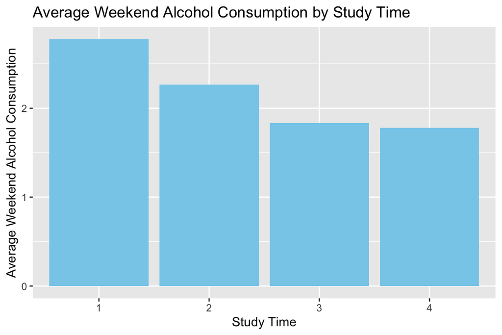

```r
# Bar plot of average Walc for each level of studytime
alc_studytime_bar_plot <- ggplot(alc, aes(x = as.factor(studytime), y = Walc)) +
  geom_bar(stat = "summary", fun = "mean", fill = "skyblue") +
  labs(title = "Average Weekend Alcohol Consumption by Study Time",
       x = "Study Time",
       y = "Average Weekend Alcohol Consumption")

print(alc_studytime_bar_plot)
```

### R code

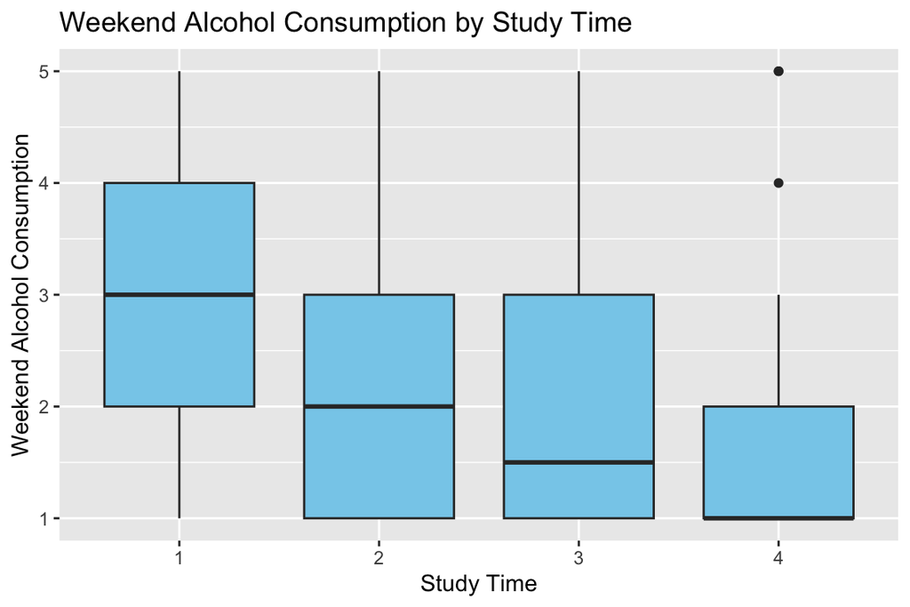

```r
# Box plot of Walc by studytime
alc_studytime_box_plot <- ggplot(alc, aes(x = as.factor(studytime), y = Walc)) +
  geom_boxplot(fill = "skyblue") +
  labs(title = "Weekend Alcohol Consumption by Study Time",
       x = "Study Time",
       y = "Weekend Alcohol Consumption")

print(alc_studytime_box_plot)
```

Alcohol consumption vary across different levels of study time and it seems that students with higher study times have lower average alcohol consumption.

Then let’s look at the distribution of alcohol consumption (‘Walc’ for weekends and ‘Dalc’ for weekdays) and its relationship with the variable ‘sex’.

### R code

```r
# Summary statistics of relevant variables
summary(alc$sex)
```

```
##    Length     Class      Mode
##       370 character character
```

```r
# Cross-tabulation of sex and Walc
cross_tab_sex <- table(alc$sex, alc$Walc)
print(cross_tab_sex)
```

```
##
##      1  2  3  4  5
##   F 87 48 43 13  4
##   M 54 32 32 34 23
```

### R code

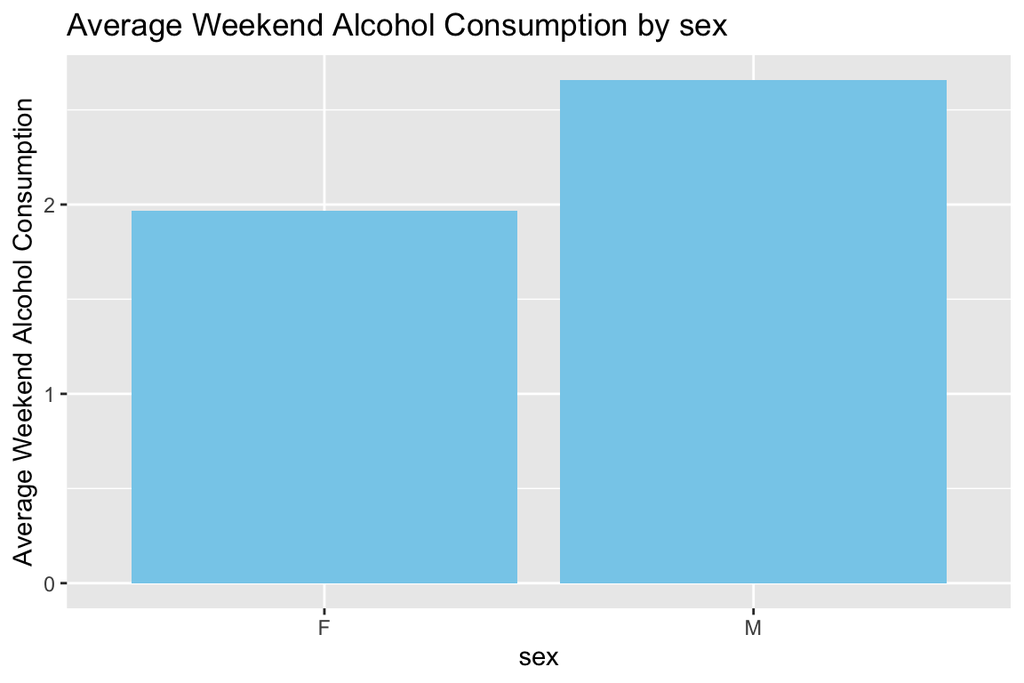

```r
# Bar plot of average Walc for each level of sex
alc_sex_bar_plot <- ggplot(alc, aes(x = as.factor(sex), y = Walc)) +
  geom_bar(stat = "summary", fun = "mean", fill = "skyblue") +
  labs(title = "Average Weekend Alcohol Consumption by sex",
       x = "sex",
       y = "Average Weekend Alcohol Consumption")

print(alc_sex_bar_plot)
```

### R code

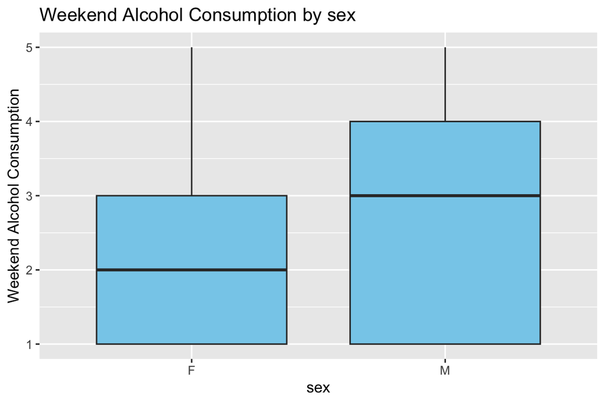

```r
# Box plot of Walc by sex
alc_sex_box_plot <- ggplot(alc, aes(x = as.factor(sex), y = Walc)) +
  geom_boxplot(fill = "skyblue") +
  labs(title = "Weekend Alcohol Consumption by sex",
       x = "sex",
       y = "Weekend Alcohol Consumption")

print(alc_sex_box_plot)
```

Average weekend alcohol consumption seems to be slightly higher with males than females.

Lastly, let’s look at the distribution of alcohol consumption (‘Walc’ for weekends) and its relationship with the variable ‘age’.

### R code

```r
# Summary statistics of age
summary(alc$age)
```

```
##    Min. 1st Qu.  Median    Mean 3rd Qu.    Max.
##   15.00   16.00   17.00   16.58   17.00   22.00
```

```r
# Cross-tabulation of age and Walc
cross_tab_age <- table(alc$age, alc$Walc)
print(cross_tab_age)
```

```
##
##       1  2  3  4  5
##   15 46 12 13  7  3
##   16 41 23 15 15  8
##   17 25 23 27 14  8
##   18 25 19 15 11  7
##   19  3  3  5  0  0
##   20  1  0  0  0  0
##   22  0  0  0  0  1
```

### R code

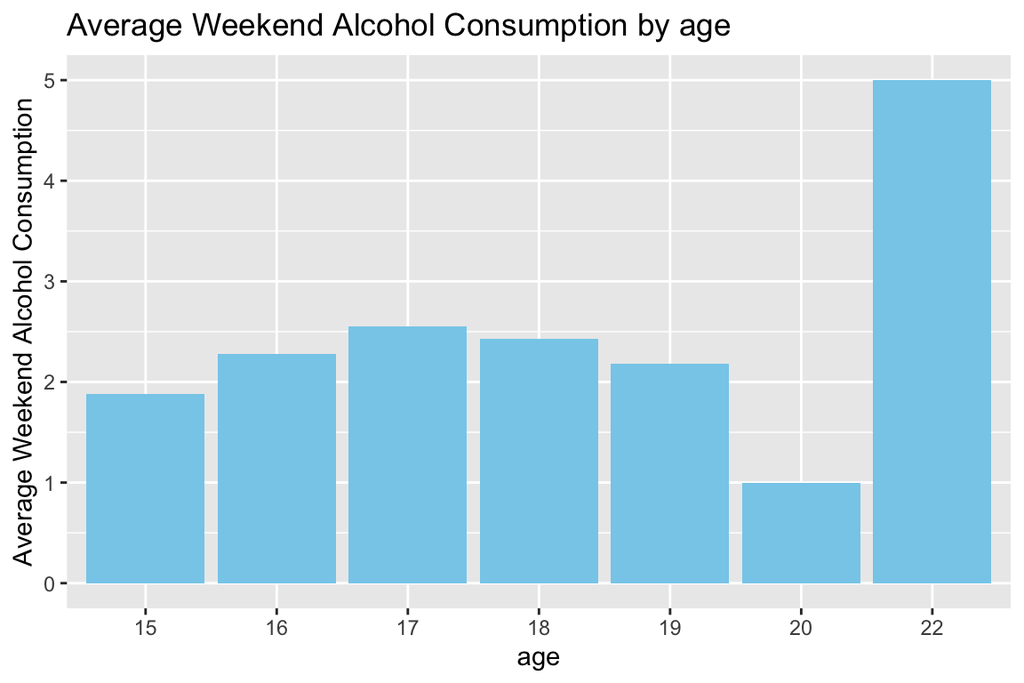

```r
# Bar plot of average Walc for each level of age
alc_age_bar_plot <- ggplot(alc, aes(x = as.factor(age), y = Walc)) +
  geom_bar(stat = "summary", fun = "mean", fill = "skyblue") +
  labs(title = "Average Weekend Alcohol Consumption by age",
       x = "age",
       y = "Average Weekend Alcohol Consumption")

print(alc_age_bar_plot)
```

### R code

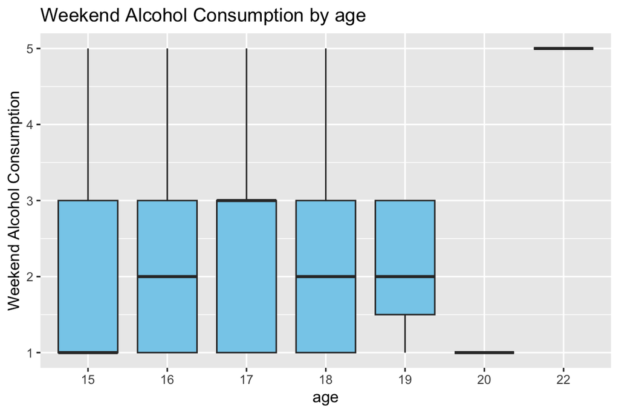

```r
# Box plot of Walc by age
alc_age_box_plot <- ggplot(alc, aes(x = as.factor(age), y = Walc)) +
  geom_boxplot(fill = "skyblue") +
  labs(title = "Weekend Alcohol Consumption by age",
       x = "age",
       y = "Weekend Alcohol Consumption")

print(alc_age_box_plot)
```

## Correlation coefficient between age and alcohol consumption

### R code

```r
# Calculate the correlation coefficient between age and Walc
correlation_walc_age <- cor(alc$age, alc$Walc)

# Print the correlation coefficient
print(correlation_walc_age)
```

```
## [1] 0.1551427
```

The correlation coefficient will be a value between -1 and 1. If the value is positive, it has positive correlation and if negative it has negative correlation. If the value is either 1 and -1 it indicates a perfect correlation, and 0 indicates no correlation.

The correlation coefficient between age and Walc is [1] 0.1551427. This value is very close to 0, but still positive so it means age has very minor but a positive correlation between alcohol consumption during the weekend.

## Generalized Linear Models

Let’s perform logistic regression model and use high_use as the binary outcome variable, and study time, sex, and age as the predictor variables. The family = “binomial” argument specifies logistic regression.

### R code

```r
# Fit logistic regression model
logistic_model <- glm(high_use ~ studytime + sex + age, data = alc, family = "binomial")

# Summarize the fitted model
summary(logistic_model)
```

```
##
## Call:
## glm(formula = high_use ~ studytime + sex + age, family = "binomial",
##     data = alc)
##
## Coefficients:
##             Estimate Std. Error z value Pr(>|z|)
## (Intercept)  -3.6554     1.7142  -2.132  0.03297 *
## studytime    -0.4972     0.1601  -3.105  0.00190 **
## sexM          0.7072     0.2474   2.858  0.00426 **
## age           0.2054     0.1008   2.037  0.04161 *
## ---
## Signif. codes:  0 '***' 0.001 '**' 0.01 '*' 0.05 '.' 0.1 ' ' 1
##
## (Dispersion parameter for binomial family taken to be 1)
##
##     Null deviance: 452.04  on 369  degrees of freedom
## Residual deviance: 421.24  on 366  degrees of freedom
## AIC: 429.24
##
## Number of Fisher Scoring iterations: 4
```

Based on this logistic regression model it seems that each predictor variable is associated with the “high_use” of alcohol. The p-values suggest that study time (p-value of 0.00190), sex (p-value of 0.00426), and age (p-value of 0.04161) are statistically significant predictors of alcohol consumption.

The coefficient for sexM and are positive. So when age increases, the “high_use” category (high alcohol consumtpion) also increases. It is also related to sex and males have higher alcohol consumption. The coefficient for studytime is negative, indicating that as study time increases, the log odds of being in the “high_use” category decrease.

### R code

```r
# Extract odds ratios and confidence intervals
odds_ratios <- exp(coef(logistic_model))
conf_intervals <- confint(logistic_model)
# Print odds ratios and confidence intervals
print("Odds Ratios:")
```

```
## [1] "Odds Ratios:"
```

```r
print(odds_ratios)
```

```
## (Intercept)   studytime        sexM         age
##  0.02585034  0.60825171  2.02832763  1.22807258
```

```r
print("Confidence Intervals:")
```

```
## [1] "Confidence Intervals:"
```

```r
print(conf_intervals)
```

```
##                    2.5 %     97.5 %
## (Intercept) -7.063114273 -0.3259619
## studytime   -0.821067712 -0.1918567
## sexM         0.224462537  1.1962918
## age          0.009734844  0.4061281
```

Odds ratio for study time is 0.60825171 –> So that means that for each one-unit increase in study time, the odds of being in the “high_use” category decreases by approximately 39.2% (1 - 0.6082).

Odds ratio for sex (sexM) is 2.02832763 –> meaning that males have approximately 2.03 times the odds of being in the “high_use” category compared to females.

Odds Ratio for age is 1.22807258 –> Each one-unit increase in age, means that the odds of being in the “high_use” category increases by approximately 22.8% (1.2281 - 1).

### R code

```r
print("Confidence Intervals:")
```

```
## [1] "Confidence Intervals:"
```

```r
print(conf_intervals)
```

```
##                    2.5 %     97.5 %
## (Intercept) -7.063114273 -0.3259619
## studytime   -0.821067712 -0.1918567
## sexM         0.224462537  1.1962918
## age          0.009734844  0.4061281
```

If confidence intervals includes 0 or 1, it suggests that the parameter is not statistically significant. In this data set, confidence intervals for study time (-0.8211, -0.1919), sex (0.2245, 1.1963) and age (0.0097, 0.4061) do not include 0 for coefficients and do not include 1 for odds ratios –> We can be 95% confident that these variables have a true effect on being in the “high_use” category and thus are statistically significant.

## predictive power of the model

### R code

```r
# Make predictions using the logistic regression model
predictions <- predict(logistic_model, type = "response")

# Convert predicted probabilities to binary predictions (0 or 1)
predicted_classes <- ifelse(predictions > 0.5, 1, 0)

# Create a data frame with actual and predicted values
prediction_df <- data.frame(Actual = alc$high_use, Predicted = predicted_classes)

# 2x2 Cross-tabulation
confusion_matrix <- table(prediction_df$Actual, prediction_df$Predicted)
print("Confusion Matrix:")
```

```
## [1] "Confusion Matrix:"
```

```r
print(confusion_matrix)
```

```
##
##           0   1
##   FALSE 244  15
##   TRUE   92  19
```

```r
# Calculate training error (proportion of inaccurately classified individuals)
training_error <- mean(prediction_df$Actual != prediction_df$Predicted)
print(paste("Training Error:", training_error))
```

```
## [1] "Training Error: 0.289189189189189"
```

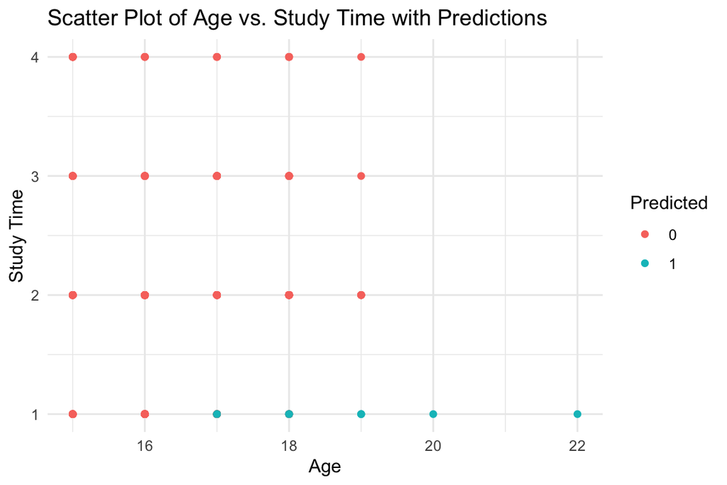

```r
# Display a graphic visualizing actual values and predictions
library(ggplot2)

# Scatter plot of age versus studytime
age_studytime_scatter_plot <- ggplot(prediction_df, aes(x = alc$age, y = alc$studytime, color = factor(Predicted))) +
  geom_point() +
  labs(title = "Scatter Plot of Age vs. Study Time with Predictions",
       x = "Age",
       y = "Study Time",
       color = "Predicted") +
  theme_minimal()

print(age_studytime_scatter_plot)
```

```r
# Remove rows with missing values in the 'high_use' column
alc_no_missing <- alc[complete.cases(alc$high_use), ]

# Compare with a simple guessing strategy for the majority class
majority_class <- as.numeric(names(sort(table(alc_no_missing$high_use), decreasing = TRUE))[1])
simple_guessing <- rep(majority_class, nrow(alc_no_missing))

# Calculate training error for the simple guessing strategy
simple_guessing_error <- mean(alc_no_missing$high_use != simple_guessing)
print(paste("Simple Guessing Error:", simple_guessing_error))
```

```
## [1] "Simple Guessing Error: NA"
```

## 10-fold cross-validation

### R code

```r
library(boot)

# Define the logistic regression model
logistic_model <- glm(high_use ~ studytime + sex + age, data = alc, family = "binomial")

# Define the logistic regression model function for cross-validation
logistic_model_func <- function(data, indices) {
  train_data <- data[indices, ]
  test_data <- data[-indices, ]

  # Fit the logistic regression model on the training data
  model <- glm(high_use ~ studytime + sex + age, data = train_data, family = "binomial")

  # Make predictions on the test data
  predictions <- predict(model, test_data, type = "response")

  # Convert predicted probabilities to binary predictions
  predicted_classes <- ifelse(predictions > 0.5, 1, 0)

  # Return the predicted classes for the test set
  return(predicted_classes)
}

# Perform 10-fold cross-validation
cv_results <- cv.glm(data = alc, glmfit = logistic_model, K = 10)

# Calculate the average error across folds
cv_error <- mean(cv_results$delta)

# Print the cross-validation error
print(paste("10-Fold Cross-Validation Error:", cv_error))
```

```
## [1] "10-Fold Cross-Validation Error: 0.197527138071811"
```

# Assignment 4: Data Analysis excercise

```r
date()
```

```
## [1] "Mon Dec  4 23:27:05 2023"
```

The Boston data set is available in R and can be downloaded from the MASS package. It contains information on housing values in suburbs of Boston. Each row represents a different town, and each column are variables that provide various aspects of the towns.

## Reading data into R

```r
# access the MASS package
library(MASS)
# load the data
data("Boston")

# explore the structure of the data set
str(Boston)
```

```
## 'data.frame':    506 obs. of  14 variables:
##  $ crim   : num  0.00632 0.02731 0.02729 0.03237 0.06905 ...
##  $ zn     : num  18 0 0 0 0 0 12.5 12.5 12.5 12.5 ...
##  $ indus  : num  2.31 7.07 7.07 2.18 2.18 2.18 7.87 7.87 7.87 7.87 ...
##  $ chas   : int  0 0 0 0 0 0 0 0 0 0 ...
##  $ nox    : num  0.538 0.469 0.469 0.458 0.458 0.458 0.524 0.524 0.524 0.524 ...
##  $ rm     : num  6.58 6.42 7.18 7 7.15 ...
##  $ age    : num  65.2 78.9 61.1 45.8 54.2 58.7 66.6 96.1 100 85.9 ...
##  $ dis    : num  4.09 4.97 4.97 6.06 6.06 ...
##  $ rad    : int  1 2 2 3 3 3 5 5 5 5 ...
##  $ tax    : num  296 242 242 222 222 222 311 311 311 311 ...
##  $ ptratio: num  15.3 17.8 17.8 18.7 18.7 18.7 15.2 15.2 15.2 15.2 ...
##  $ black  : num  397 397 393 395 397 ...
##  $ lstat  : num  4.98 9.14 4.03 2.94 5.33 ...
##  $ medv   : num  24 21.6 34.7 33.4 36.2 28.7 22.9 27.1 16.5 18.9 ...
```

```r
# exlpore the dimension of the data set
dim(Boston)
```

```
## [1] 506  14
```